# Descriptive Exit Analysis

Exit Analysis

## Table of contents

1. Introduction
2. Data Collection
3. Explanatory Data Analysis
4. Questions & Answers

## Introduction

In XYZ company, many employees leave each month. The stackholders want to know facts about employees who leave, so the recrutment will be ready and will keep an enough supply for hot jobs that employees leave it, this is on one hand. On the other hand, they want to know what rules have less lifespan more than others. In this analysis, we will explore the date from the employees' service certificates.

```
Imported Necessary libs
```

# DATA Collection process

### A script was prepared to collect data from word file forms (Service Certificates) and gathers the data in excel file

### The information in the pink box were extracted for the prupose of this Analysis.

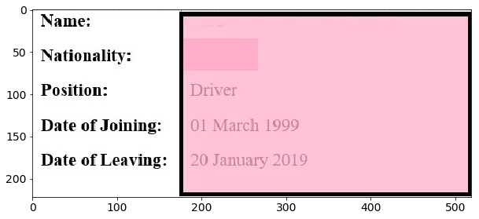

### After Extracting the data, the data was cleaned and prepared for the Analysis.

# Explanatory Data Analysis

| leave | nat | job | join | empno | dept | service |
| --- | --- | --- | --- | --- | --- | --- |
| 2019-09-01 | Nepalese | Merchandiser | 2017-10-15 | 2344 | General Products Department | 1.879452 |
| 2019-09-01 | Indian | Van Salesman | 2014-09-13 | 1927 | Consumer Products Department | 4.969863 |
| 2019-09-01 | Nepalese | Warehouse Asst | 2012-05-12 | 1587 | Logistics Department | 7.309589 |
| 2019-09-01 | Sri-Lankan | Sales Supervisor | 2006-12-16 | 1107 | Consumer Electronics & Home Appliances Department | 12.717808 |
| 2019-08-28 | Nepalese | Driver | 2006-11-30 | 1093 | Logistics Department | 12.750685 |

# What are the minimum, maximum and average service period for employee?

|  | service |
| --- | --- |
| count | 517.000000 |
| mean | 6.616942 |
| std | 6.319235 |
| min | 0.449315 |
| 25% | 2.345205 |
| 50% | 4.495890 |
| 75% | 8.663014 |
| max | 39.057534 |

### **Explaining the summary**

- The number of records is **517** service certificate.
- We can see that the average service period for employee is **6.6** years.
- We can see that the standard deviation is **6.3** years > which is considered high and means that data includes wide range of values.
- The minimum service period is **0.4** year which means 5 month.
- The first quartile is **2.35** years.
- The Second quartile - Median is **4.4** years.
- The third quartile is **8.6** years.
- The interquartile range (IQR) is 8.66 - 2.35 = **6.31** years.
- The maximum service period is **39** years.

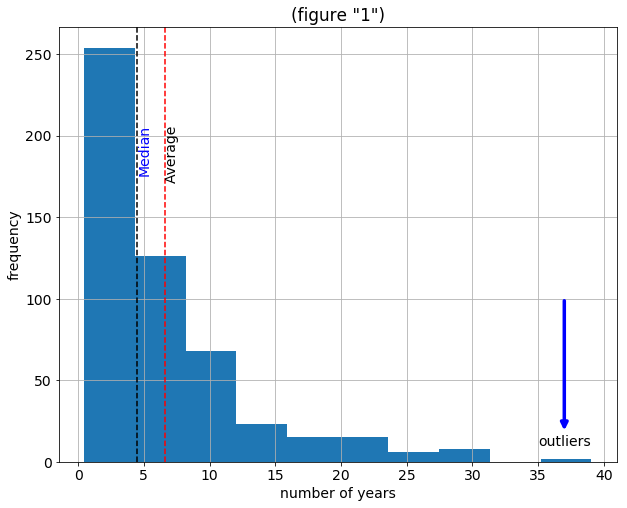

### explaining histogram (figure 1)

- We notice that the sample has positive skewness.
- More than 250 employees did not compelete 5 years at least in the company
- we can see on the right side, there is a few number of employees they worked for more than 30 years, they are outliers. #### As we have outliers, using The Average (mean) ~6.6~ will be misleading, it is better to use median **4.4** as a less misleading value for the average of service period for the employee

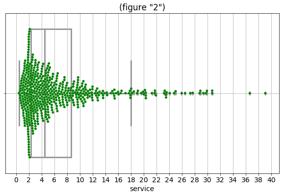

### Explaining Box plot (figure 2)

#### We notice that most of population is between 0.4 and 8.5 years.

#### Employees who spent more than 18 years are considered outliers (too far from the average employees).

# What are the nationalities that tend to leave the company more than the others?

|  | percentages | counts |
| --- | --- | --- |
| Nepalese | 44.487427 | 230 |
| Indian | 17.794971 | 92 |
| Sri-Lankan | 16.247582 | 84 |
| Filipino | 13.539652 | 70 |
| Egyptian | 2.127660 | 11 |
| Kenyan | 1.353965 | 7 |
| Pakistani | 0.967118 | 5 |
| Jordanian | 0.773694 | 4 |
| Bangladeshi | 0.773694 | 4 |
| Tunisian | 0.580271 | 3 |
| Ghanaian | 0.386847 | 2 |
| Lebanese | 0.193424 | 1 |
| Iranian | 0.193424 | 1 |
| Algerian | 0.193424 | 1 |
| Sudanese | 0.193424 | 1 |
| Moroccan | 0.193424 | 1 |

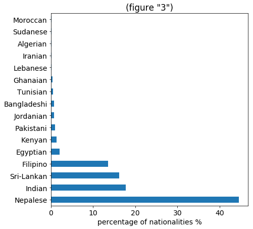

### Nationalities column statistics (figure 3)

#### We notice that the dominant nationalities of the sample are Nepalese, Indians, Sri-Lankans and Filipinos (As they represent the most of the company's population)

# What are the top 10 positions that they tend to leave the company more than others?

|  | percentages | counts |
| --- | --- | --- |
| Merchandiser | 23.017408 | 119 |
| Driver | 5.996132 | 31 |
| Helper | 5.802708 | 30 |
| Sales Executive | 5.415861 | 28 |
| Technician | 3.481625 | 18 |
| Technician - Air Cons | 2.127660 | 11 |
| Senior Sales Executive | 1.934236 | 10 |
| Assistant Sales Executive | 1.934236 | 10 |
| Van Salesman | 1.934236 | 10 |
| Senior Technician | 1.934236 | 10 |

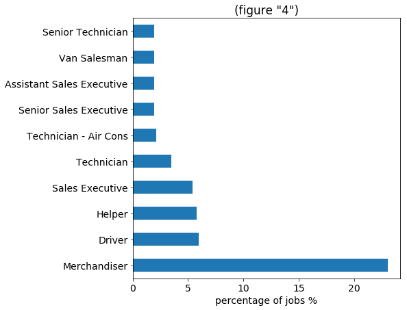

### Positions/jobs column statistics (figure 4)

#### There are too many jobs, however we choose to show only the top 10 jobs in order to display them properly

#### We notice that most of percentage of the sample is Merchanidisers.

#### Knowing the hot jobs that they require recruting on fast pace will make the company always ready to face these changes without interrupting the workflow.

# What is the average number of people they are leaving each month/quarter/year?

```
The expected amount of employees to leave per month are: 9.0
per Quarter: 27.0
per half year: 52.0
per year 103.0
```

# General year-month Statistics

| leave | nat 1 | nat 2 | nat 3 | nat 4 | nat 5 | nat 6 | nat 7 | nat 8 | nat 9 | nat 10 | nat 11 | nat 12 | Total_per_year |
| --- | --- | --- | --- | --- | --- | --- | --- | --- | --- | --- | --- | --- | --- |
| 2014 | 0.0 | 0.0 | 0.0 | 0.0 | 0.0 | 0.0 | 0.0 | 0.0 | 0.0 | 0.0 | 2.0 | 0.0 | 2 |
| 2015 | 0.0 | 0.0 | 0.0 | 0.0 | 2.0 | 0.0 | 0.0 | 1.0 | 11.0 | 5.0 | 4.0 | 4.0 | 27 |
| 2016 | 3.0 | 2.0 | 4.0 | 5.0 | 8.0 | 4.0 | 8.0 | 5.0 | 9.0 | 3.0 | 4.0 | 15.0 | 70 |
| 2017 | 12.0 | 12.0 | 25.0 | 4.0 | 31.0 | 7.0 | 23.0 | 30.0 | 7.0 | 22.0 | 16.0 | 13.0 | 202 |
| 2018 | 15.0 | 14.0 | 9.0 | 2.0 | 8.0 | 7.0 | 5.0 | 11.0 | 6.0 | 16.0 | 7.0 | 10.0 | 110 |
| 2019 | 23.0 | 8.0 | 12.0 | 9.0 | 10.0 | 6.0 | 9.0 | 9.0 | 11.0 | 4.0 | 5.0 | 0.0 | 106 |

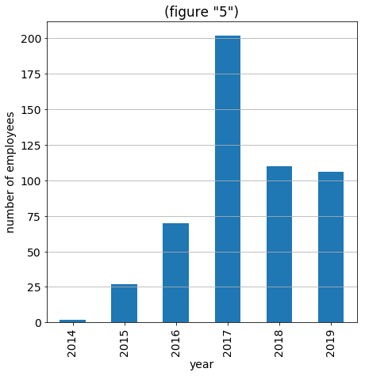

### Year statistics (figure 5)

#### We notice from the table that 2014 the data is not complete and also in 2015.

#### The years that have the full data of all months are 2016, 2017, and 2018.

#### As this analysis were made by the end of Nov. 2019, December is not completed yet.

#### 2017 has the peak if we compared it to the other full years in 2016, 2018, which may indicate major incident or event affected the exit rate of employees.

| Month over years | 1 | 2 | 3 | 4 | 5 | 6 | 7 | 8 | 9 | 10 | 11 | 12 |
| --- | --- | --- | --- | --- | --- | --- | --- | --- | --- | --- | --- | --- |
| number of employees | 53 | 36 | 50 | 20 | 59 | 24 | 45 | 56 | 44 | 50 | 38 | 42 |

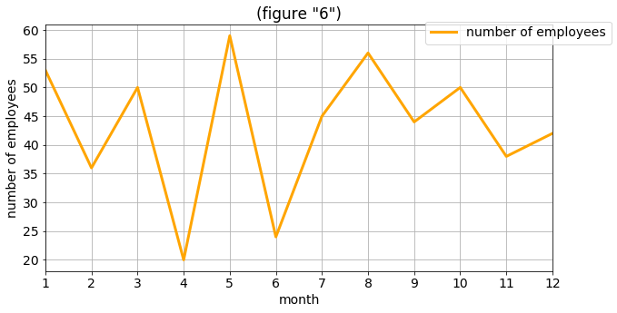

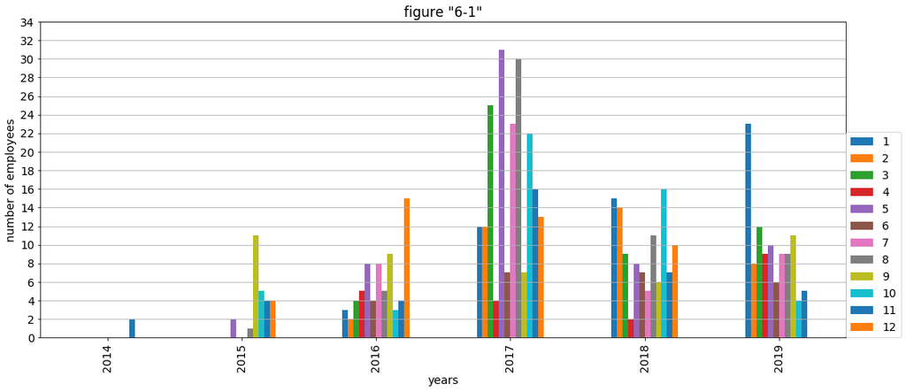

| leave | 1 | 2 | 3 | 4 | 5 | 6 | 7 | 8 | 9 | 10 | 11 | 12 |
| --- | --- | --- | --- | --- | --- | --- | --- | --- | --- | --- | --- | --- |
| 2014 | 0.0 | 0.0 | 0.0 | 0.0 | 0.0 | 0.0 | 0.0 | 0.0 | 0.0 | 0.0 | 2.0 | 0.0 |
| 2015 | 0.0 | 0.0 | 0.0 | 0.0 | 2.0 | 0.0 | 0.0 | 1.0 | 11.0 | 5.0 | 4.0 | 4.0 |
| 2016 | 3.0 | 2.0 | 4.0 | 5.0 | 8.0 | 4.0 | 8.0 | 5.0 | 9.0 | 3.0 | 4.0 | 15.0 |
| 2017 | 12.0 | 12.0 | 25.0 | 4.0 | 31.0 | 7.0 | 23.0 | 30.0 | 7.0 | 22.0 | 16.0 | 13.0 |
| 2018 | 15.0 | 14.0 | 9.0 | 2.0 | 8.0 | 7.0 | 5.0 | 11.0 | 6.0 | 16.0 | 7.0 | 10.0 |
| 2019 | 23.0 | 8.0 | 12.0 | 9.0 | 10.0 | 6.0 | 9.0 | 9.0 | 11.0 | 4.0 | 5.0 | 0.0 |

### Month statistics (figure 6)

#### We notice from the table that may is highest month at all, however it is highest in the peak year 2017 which affects the total.

#### Despite the fact that May is highest ever, in other years it is normal but we notice its always higher than April and June.

#### August had also higher rates in 2017 affected its performance in overall

### Month statistics (figure 6-1)

#### providing a chart of all months in each year in order to compare them to each other

| job | Assistant Sales Executive | Driver | Helper | Merchandiser | Sales Executive | Senior Sales Executive | Senior Technician | Technician | Technician - Air Cons | Van Salesman |
| --- | --- | --- | --- | --- | --- | --- | --- | --- | --- | --- |
| 1 | 0.0000 | 5.660 | 5.660000 | 22.6400 | 5.660000 | 5.660000 | 1.8900 | 0.0000 | 3.7700 | 1.890000 |
| 2 | 2.7800 | 0.000 | 2.780000 | 30.5600 | 5.560000 | 2.780000 | 0.0000 | 5.5600 | 2.7800 | 0.000000 |
| 3 | 2.0000 | 4.000 | 6.000000 | 24.0000 | 6.000000 | 4.000000 | 2.0000 | 0.0000 | 0.0000 | 2.000000 |
| 4 | 5.0000 | 10.000 | 5.000000 | 15.0000 | 20.000000 | 0.000000 | 0.0000 | 0.0000 | 0.0000 | 0.000000 |
| 5 | 6.7800 | 8.470 | 5.080000 | 20.3400 | 6.780000 | 0.000000 | 0.0000 | 5.0800 | 0.0000 | 3.390000 |
| 6 | 0.0000 | 12.500 | 0.000000 | 29.1700 | 4.170000 | 4.170000 | 0.0000 | 4.1700 | 4.1700 | 0.000000 |
| 7 | 0.0000 | 8.890 | 13.330000 | 15.5600 | 0.000000 | 0.000000 | 4.4400 | 0.0000 | 0.0000 | 0.000000 |
| 8 | 1.7900 | 7.140 | 1.790000 | 28.5700 | 1.790000 | 1.790000 | 0.0000 | 3.5700 | 1.7900 | 3.570000 |
| 9 | 0.0000 | 4.550 | 18.180000 | 20.4500 | 2.270000 | 0.000000 | 4.5500 | 4.5500 | 0.0000 | 4.550000 |
| 10 | 4.0000 | 8.000 | 4.000000 | 20.0000 | 6.000000 | 0.000000 | 6.0000 | 8.0000 | 6.0000 | 2.000000 |
| 11 | 0.0000 | 2.630 | 2.630000 | 34.2100 | 5.260000 | 2.630000 | 2.6300 | 5.2600 | 0.0000 | 0.000000 |
| 12 | 0.0000 | 2.380 | 2.380000 | 16.6700 | 9.520000 | 2.380000 | 0.0000 | 4.7600 | 7.1400 | 2.380000 |
| Minimum | 0.0000 | 0.000 | 0.000000 | 15.0000 | 0.000000 | 0.000000 | 0.0000 | 0.0000 | 0.0000 | 0.000000 |
| Average | 1.8625 | 6.185 | 5.569167 | 23.0975 | 6.084167 | 1.950833 | 1.7925 | 3.4125 | 2.1375 | 1.648333 |
| Maximum | 6.7800 | 12.500 | 18.180000 | 34.2100 | 20.000000 | 5.660000 | 6.0000 | 8.0000 | 7.1400 | 4.550000 |

## Explaining table of top 10 jobs percentages

- **The table shows the percentage of each job that left in each month over all the years.**
- **The minimum and maximum and average are the expected rate for each of these jobs to leave each month**  
  #### for example if there is 100 employees leave the company per month, it is expected that the average around 23% of them will be Merchandisers and up to 34% or more of total number of employees will be Merchandisers.  
  ### **As we saw above the average employees they leave the company every month around 10 employees, we expect 2:3 or more to be Merchandisers.**

# What are the highest and lowest months?

```
'The lowest month'
```

| leave | nat 1 | nat 2 | nat 3 | nat 4 | nat 5 | nat 6 | nat 7 | nat 8 | nat 9 | nat 10 | nat 11 | nat 12 |
| --- | --- | --- | --- | --- | --- | --- | --- | --- | --- | --- | --- | --- |
| 2014 | NaN | NaN | NaN | NaN | NaN | NaN | NaN | NaN | NaN | NaN | NaN | NaN |
| 2015 | NaN | NaN | NaN | NaN | NaN | NaN | NaN | 1.0 | NaN | NaN | NaN | NaN |
| 2016 | NaN | NaN | NaN | NaN | NaN | NaN | NaN | NaN | NaN | NaN | NaN | NaN |
| 2017 | NaN | NaN | NaN | NaN | NaN | NaN | NaN | NaN | NaN | NaN | NaN | NaN |
| 2018 | NaN | NaN | NaN | NaN | NaN | NaN | NaN | NaN | NaN | NaN | NaN | NaN |
| 2019 | NaN | NaN | NaN | NaN | NaN | NaN | NaN | NaN | NaN | NaN | NaN | NaN |

```
'The highest month'
```

| leave | nat 1 | nat 2 | nat 3 | nat 4 | nat 5 | nat 6 | nat 7 | nat 8 | nat 9 | nat 10 | nat 11 | nat 12 |
| --- | --- | --- | --- | --- | --- | --- | --- | --- | --- | --- | --- | --- |
| 2014 | NaN | NaN | NaN | NaN | NaN | NaN | NaN | NaN | NaN | NaN | NaN | NaN |
| 2015 | NaN | NaN | NaN | NaN | NaN | NaN | NaN | NaN | NaN | NaN | NaN | NaN |
| 2016 | NaN | NaN | NaN | NaN | NaN | NaN | NaN | NaN | NaN | NaN | NaN | NaN |
| 2017 | NaN | NaN | NaN | NaN | 31.0 | NaN | NaN | NaN | NaN | NaN | NaN | NaN |
| 2018 | NaN | NaN | NaN | NaN | NaN | NaN | NaN | NaN | NaN | NaN | NaN | NaN |
| 2019 | NaN | NaN | NaN | NaN | NaN | NaN | NaN | NaN | NaN | NaN | NaN | NaN |

#### We see that the lowest month is August 2015, this is because the employee was assigned the task of certificates prepration and the old certificates prepared upon request.

#### The maximum number was in May 2017.

# What is the higest department in employees left and what are the departments that they have less service periods?

|  | dept |
| --- | --- |
| Consumer Products Department | 111 |
| Logistics Department | 102 |
| Consumer Electronics & Home Appliances Department | 70 |
| Home Appliances Service Center | 56 |
| General Products Department | 50 |
| Office Equipment Service Center | 38 |
| Office Furniture & Furnishing Department | 34 |
| Office Equipment & Business Solutions Department | 27 |
| Finance Department | 15 |
| Human Resources & Administration Department | 10 |
| IT Department | 2 |
| Directors Office | 2 |

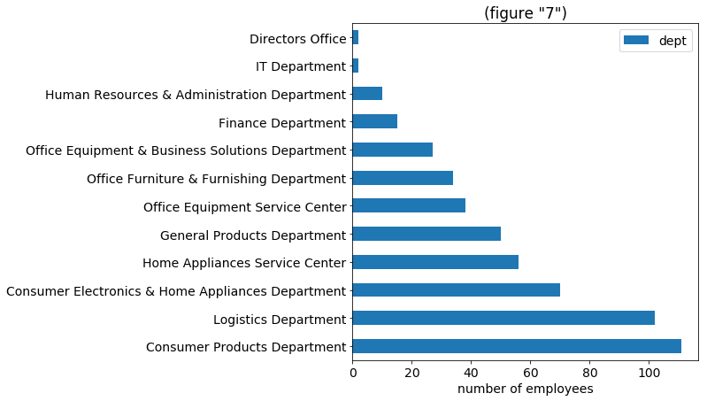

#### We notice **(figure 7)** that Consumer Products department has the highest exit rate.

#### The lowest rate in Directors office and IT as the total number of employees in these departments are extremely low.

#### We notice also that HR and Finance Departments are stable and have less number of employees.

| dept | service |
| --- | --- |
| Directors Office | 11.636986 |
| Finance Department | 10.147580 |
| Human Resources & Administration Department | 9.830137 |
| Home Appliances Service Center | 9.733953 |
| Office Equipment Service Center | 7.514348 |
| Office Furniture & Furnishing Department | 7.296454 |
| Logistics Department | 6.725813 |
| IT Department | 5.669863 |
| Consumer Electronics & Home Appliances Department | 5.659765 |
| General Products Department | 5.644932 |
| Office Equipment & Business Solutions Department | 5.488179 |
| Consumer Products Department | 4.905048 |

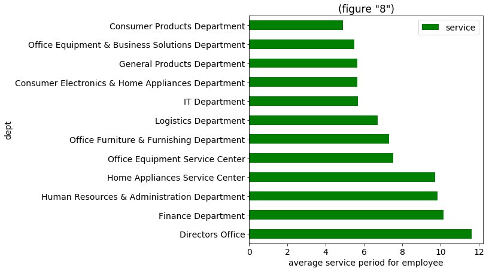

#### In last table and plot **(figure 8)**, if we excluded IT and Directors for their low numbers, we will find that Finance department has higher rates of employee service and stability and on the other hand Consumer Products Department is not stable and it has one of hot positions that requires continuous hiring.

# **Final Notes:**

## - The data were collected from word files.

## - All the service certificates were prepared at the times of the employee vacation were not in the dataset, another employee was assigned to prepare the Certificates. Thus, there is some missing data.

## - In order to improve the data and get more accurate results, it is better to acquire the data from the from the company system as it will be complete without any missing values.